# Cars_Price_Analysis

We load a file that has information about car prices and car characteristics ("CarPrice_Assignments.csv)

source : https://archive.ics.uci.edu/ml/datasets/Automobile

First we load the data, and we display the 5 first rows. The data is seperated by commas, and the headers for each column do not need any changes. Also there is no need to skip any rows from the file.

```python
import numpy as np
import pandas as pd
from matplotlib import pyplot as plt
%matplotlib inline

file_name = "CarPrice_Assignment.csv"
df = pd.read_csv(file_name,sep=",")
df.head(5)
```

|  | car_ID | symboling | CarName | fueltype | aspiration | doornumber | carbody | drivewheel | enginelocation | wheelbase | ... | enginesize | fuelsystem | boreratio | stroke | compressionratio | horsepower | peakrpm | citympg | highwaympg | price |
| --- | --- | --- | --- | --- | --- | --- | --- | --- | --- | --- | --- | --- | --- | --- | --- | --- | --- | --- | --- | --- | --- |
| 0 | 1 | 3 | alfa-romero giulia | gas | std | two | convertible | rwd | front | 88.6 | ... | 130 | mpfi | 3.47 | 2.68 | 9.0 | 111 | 5000 | 21 | 27 | 13495.0 |
| 1 | 2 | 3 | alfa-romero stelvio | gas | std | two | convertible | rwd | front | 88.6 | ... | 130 | mpfi | 3.47 | 2.68 | 9.0 | 111 | 5000 | 21 | 27 | 16500.0 |
| 2 | 3 | 1 | alfa-romero Quadrifoglio | gas | std | two | hatchback | rwd | front | 94.5 | ... | 152 | mpfi | 2.68 | 3.47 | 9.0 | 154 | 5000 | 19 | 26 | 16500.0 |
| 3 | 4 | 2 | audi 100 ls | gas | std | four | sedan | fwd | front | 99.8 | ... | 109 | mpfi | 3.19 | 3.40 | 10.0 | 102 | 5500 | 24 | 30 | 13950.0 |
| 4 | 5 | 2 | audi 100ls | gas | std | four | sedan | 4wd | front | 99.4 | ... | 136 | mpfi | 3.19 | 3.40 | 8.0 | 115 | 5500 | 18 | 22 | 17450.0 |

5 rows × 26 columns

We identify the "price" column of the dataframe to be our response/target variable that we would like to predict.

The other variables of the dataframe will be our predictors.

We search what is the data type of each variable

```python
df.dtypes
```

```
car_ID                int64
symboling             int64
CarName              object
fueltype             object
aspiration           object
doornumber           object
carbody              object
drivewheel           object
enginelocation       object
wheelbase           float64
carlength           float64
carwidth            float64
carheight           float64
curbweight            int64
enginetype           object
cylindernumber       object
enginesize            int64
fuelsystem           object
boreratio           float64
stroke              float64
compressionratio    float64
horsepower            int64
peakrpm               int64
citympg               int64
highwaympg            int64
price               float64
dtype: object
```

We see that the dataframe contains both categorical and numeric variables. The "price" variable is float64 (which is correct since we want to be numeric variable) so we do not change its type.

The types of each variable are correct, so we continue with a statistical summary of our data in order to get a glance of what we are dealing with.

```python
pd.set_option('display.max_rows',205,'display.max_columns',26)
df.describe(include="all")  # we added the include="all" in order to examine categorical variables as well
```

|  | car_ID | symboling | CarName | fueltype | aspiration | doornumber | carbody | drivewheel | enginelocation | wheelbase | carlength | carwidth | carheight | curbweight | enginetype | cylindernumber | enginesize | fuelsystem | boreratio | stroke | compressionratio | horsepower | peakrpm | citympg | highwaympg | price |
| --- | --- | --- | --- | --- | --- | --- | --- | --- | --- | --- | --- | --- | --- | --- | --- | --- | --- | --- | --- | --- | --- | --- | --- | --- | --- | --- |
| count | 205.000000 | 205.000000 | 205 | 205 | 205 | 205 | 205 | 205 | 205 | 205.000000 | 205.000000 | 205.000000 | 205.000000 | 205.000000 | 205 | 205 | 205.000000 | 205 | 205.000000 | 205.000000 | 205.000000 | 205.000000 | 205.000000 | 205.000000 | 205.000000 | 205.000000 |
| unique | NaN | NaN | 147 | 2 | 2 | 2 | 5 | 3 | 2 | NaN | NaN | NaN | NaN | NaN | 7 | 7 | NaN | 8 | NaN | NaN | NaN | NaN | NaN | NaN | NaN | NaN |
| top | NaN | NaN | toyota corona | gas | std | four | sedan | fwd | front | NaN | NaN | NaN | NaN | NaN | ohc | four | NaN | mpfi | NaN | NaN | NaN | NaN | NaN | NaN | NaN | NaN |
| freq | NaN | NaN | 6 | 185 | 168 | 115 | 96 | 120 | 202 | NaN | NaN | NaN | NaN | NaN | 148 | 159 | NaN | 94 | NaN | NaN | NaN | NaN | NaN | NaN | NaN | NaN |
| mean | 103.000000 | 0.834146 | NaN | NaN | NaN | NaN | NaN | NaN | NaN | 98.756585 | 174.049268 | 65.907805 | 53.724878 | 2555.565854 | NaN | NaN | 126.907317 | NaN | 3.329756 | 3.255415 | 10.142537 | 104.117073 | 5125.121951 | 25.219512 | 30.751220 | 13276.710571 |
| std | 59.322565 | 1.245307 | NaN | NaN | NaN | NaN | NaN | NaN | NaN | 6.021776 | 12.337289 | 2.145204 | 2.443522 | 520.680204 | NaN | NaN | 41.642693 | NaN | 0.270844 | 0.313597 | 3.972040 | 39.544167 | 476.985643 | 6.542142 | 6.886443 | 7988.852332 |
| min | 1.000000 | -2.000000 | NaN | NaN | NaN | NaN | NaN | NaN | NaN | 86.600000 | 141.100000 | 60.300000 | 47.800000 | 1488.000000 | NaN | NaN | 61.000000 | NaN | 2.540000 | 2.070000 | 7.000000 | 48.000000 | 4150.000000 | 13.000000 | 16.000000 | 5118.000000 |
| 25% | 52.000000 | 0.000000 | NaN | NaN | NaN | NaN | NaN | NaN | NaN | 94.500000 | 166.300000 | 64.100000 | 52.000000 | 2145.000000 | NaN | NaN | 97.000000 | NaN | 3.150000 | 3.110000 | 8.600000 | 70.000000 | 4800.000000 | 19.000000 | 25.000000 | 7788.000000 |
| 50% | 103.000000 | 1.000000 | NaN | NaN | NaN | NaN | NaN | NaN | NaN | 97.000000 | 173.200000 | 65.500000 | 54.100000 | 2414.000000 | NaN | NaN | 120.000000 | NaN | 3.310000 | 3.290000 | 9.000000 | 95.000000 | 5200.000000 | 24.000000 | 30.000000 | 10295.000000 |
| 75% | 154.000000 | 2.000000 | NaN | NaN | NaN | NaN | NaN | NaN | NaN | 102.400000 | 183.100000 | 66.900000 | 55.500000 | 2935.000000 | NaN | NaN | 141.000000 | NaN | 3.580000 | 3.410000 | 9.400000 | 116.000000 | 5500.000000 | 30.000000 | 34.000000 | 16503.000000 |
| max | 205.000000 | 3.000000 | NaN | NaN | NaN | NaN | NaN | NaN | NaN | 120.900000 | 208.100000 | 72.300000 | 59.800000 | 4066.000000 | NaN | NaN | 326.000000 | NaN | 3.940000 | 4.170000 | 23.000000 | 288.000000 | 6600.000000 | 49.000000 | 54.000000 | 45400.000000 |

Thus, the dataset includes cars of all types (fast and powerful to small fuel-efficient), so the price differs among them. There are very expensive and low-price cars, which will enable us to do a rich analysis on their price.

Now, we check if there are NaNs in our dataset so that we can handle them.

```python
nan_df = df.isna()
# print(nan_df)
nan_rows = nan_df.any(axis=1)
print(nan_rows)
```

```
0      False
1      False
2      False
3      False
4      False
5      False
6      False
7      False
8      False
9      False
10     False
11     False
12     False
13     False
14     False
```

[output cut: 191 more lines]

As we can see there are no NaNs. We check if the categorical variables have the same name conventions, so that we can group their values correctly.

```python
print(df['fueltype'].unique())
print(df['aspiration'].unique())
print(df['doornumber'].unique())
print(df['carbody'].unique())
print(df['drivewheel'].unique())
print(df['enginelocation'].unique())
print(df['enginetype'].unique())
# it looks like the "dohcv" is mispelled and it should be written as "dohc"
df['enginetype'].replace('dohcv','dohc',inplace=True)
print(df['enginetype'].unique())
print(df['cylindernumber'].unique())
# regarding "cylindernumber" it is better to convert it to numeric variable which will include integers
df['cylindernumber'].replace({'four':4,'six':6,'five':5,'three':3,'twelve':12,'two':2,'eight':8},inplace=True)
df['cylindernumber'].astype('int')
print(df['fuelsystem'].unique())
```

```
['gas' 'diesel']
['std' 'turbo']
['two' 'four']
['convertible' 'hatchback' 'sedan' 'wagon' 'hardtop']
['rwd' 'fwd' '4wd']
['front' 'rear']
['dohc' 'ohcv' 'ohc' 'l' 'rotor' 'ohcf' 'dohcv']
['dohc' 'ohcv' 'ohc' 'l' 'rotor' 'ohcf']
['four' 'six' 'five' 'three' 'twelve' 'two' 'eight']
['mpfi' '2bbl' 'mfi' '1bbl' 'spfi' '4bbl' 'idi' 'spdi']
```

We have checked the mispelled entries and now we want to convert the miles per gallon to kilometers per liter for the two variables "citympg" and "highwaympg" ( 1 m/g = 0.425 km/L)

```python
df['citympg'] = 0.425*df['citympg']
df.rename(columns={"citympg":"city-km/L"},inplace=True)
df['highwaympg'] = 0.425*df['highwaympg']
df.rename(columns={"highwaympg":"highway-km/L"},inplace=True)
print(df.head(2))
```

```
   car_ID  symboling              CarName fueltype aspiration doornumber  \
0       1          3   alfa-romero giulia      gas        std        two
1       2          3  alfa-romero stelvio      gas        std        two

       carbody drivewheel enginelocation  wheelbase  carlength  carwidth  \
0  convertible        rwd          front       88.6      168.8      64.1
1  convertible        rwd          front       88.6      168.8      64.1

   carheight  curbweight enginetype  cylindernumber  enginesize fuelsystem  \
0       48.8        2548       dohc               4         130       mpfi
1       48.8        2548       dohc               4         130       mpfi

   boreratio  stroke  compressionratio  horsepower  peakrpm  city-km/L  \
0       3.47    2.68               9.0         111     5000      8.925
1       3.47    2.68               9.0         111     5000      8.925

   highway-km/L    price
0        11.475  13495.0
1        11.475  16500.0
```

Due to the fact that some variables are 3 orders of magnitude like peakrpm and some others are 1 order such as boreratio, we normalize all the numeric variables with the "min-max" way so that all numeric variables span from 0 to 1.

```python
df['symboling'] = (df['symboling']-df['symboling'].min())/(df['symboling'].max()-df['symboling'].min())
df['wheelbase'] = (df['wheelbase']-df['wheelbase'].min())/(df['wheelbase'].max()-df['wheelbase'].min())
df['carlength'] = (df['carlength']-df['carlength'].min())/(df['carlength'].max()-df['carlength'].min())
df['carwidth'] = (df['carwidth']-df['carwidth'].min())/(df['carwidth'].max()-df['carwidth'].min())
df['carheight'] = (df['carheight']-df['carheight'].min())/(df['carheight'].max()-df['carheight'].min())
df['curbweight'] = (df['curbweight']-df['curbweight'].min())/(df['curbweight'].max()-df['curbweight'].min())
df['enginesize'] = (df['enginesize']-df['enginesize'].min())/(df['enginesize'].max()-df['enginesize'].min())
df['boreratio'] = (df['boreratio']-df['boreratio'].min())/(df['boreratio'].max()-df['boreratio'].min())
df['stroke'] = (df['stroke']-df['stroke'].min())/(df['stroke'].max()-df['stroke'].min())
df['compressionratio'] = (df['compressionratio']-df['compressionratio'].min())/(df['compressionratio'].max()-df['compressionratio'].min())
df['horsepower'] = (df['horsepower']-df['horsepower'].min())/(df['horsepower'].max()-df['horsepower'].min())
df['peakrpm'] = (df['peakrpm']-df['peakrpm'].min())/(df['peakrpm'].max()-df['peakrpm'].min())
df['city-km/L'] = (df['city-km/L']-df['city-km/L'].min())/(df['city-km/L'].max()-df['city-km/L'].min())
df['highway-km/L'] = (df['highway-km/L']-df['highway-km/L'].min())/(df['highway-km/L'].max()-df['highway-km/L'].min())
print(df.head(2))
```

```
   car_ID  symboling              CarName fueltype aspiration doornumber  \
0       1        1.0   alfa-romero giulia      gas        std        two
1       2        1.0  alfa-romero stelvio      gas        std        two

       carbody drivewheel enginelocation  wheelbase  carlength  carwidth  \
0  convertible        rwd          front   0.058309   0.413433  0.316667
1  convertible        rwd          front   0.058309   0.413433  0.316667

   carheight  curbweight enginetype  cylindernumber  enginesize fuelsystem  \
0   0.083333    0.411171       dohc               4    0.260377       mpfi
1   0.083333    0.411171       dohc               4    0.260377       mpfi

   boreratio    stroke  compressionratio  horsepower   peakrpm  city-km/L  \
0   0.664286  0.290476             0.125      0.2625  0.346939   0.222222
1   0.664286  0.290476             0.125      0.2625  0.346939   0.222222

   highway-km/L    price
0      0.289474  13495.0
1      0.289474  16500.0
```

Let's now examine the car price distribution.

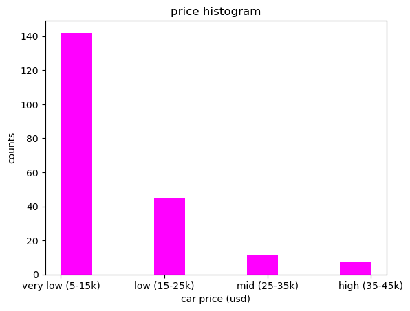

```
                  count
price category
very low (5-15k)    142
low (15-25k)         45
mid (25-35k)         11
high (35-45k)         7
```

```python
bins1 = np.linspace(df['price'].min(),df['price'].max(),5)
mylabels = ['very low (5-15k)','low (15-25k)','mid (25-35k)','high (35-45k)']
df['price_cat']=pd.cut(df['price'],bins1,labels=mylabels,include_lowest=True)
plt.hist(df['price_cat'],color='magenta')
plt.title('price histogram')
plt.xlabel('car price (usd)')
plt.ylabel('counts')
plt.show()

df_price_counts=df['price_cat'].value_counts().to_frame()
df_price_counts.rename(columns={'price_cat':'counts'},inplace=True)
df_price_counts.index.name='price category'
print(df_price_counts)
```

From the above figure we infer that we are dealing with mostly economic cars (#187). Nethertheless, the dataset includes some mid-to-high cost cars (#18). That is not necessarily bad since most people cannot afford to buy luxury cars, etc.

We examine how categorical variables affect the car price by constructing some pivot tables.

```
                   price
aspiration           std         turbo
fueltype
diesel       9670.571429  19159.153846
gas         12739.127329  14748.465292
```

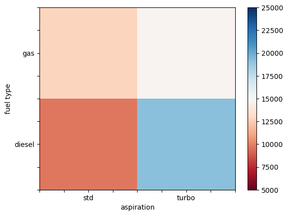

```
                    price
drivewheel            4wd           fwd           rwd
carbody
convertible      0.000000  11595.000000  23949.600000
hardtop          0.000000   8249.000000  24202.714286
hatchback    12731.083500   8396.387755  15235.815789
sedan        12647.333333   9780.385965  21711.833333
wagon         9095.750000   9997.333333  16994.222222
```

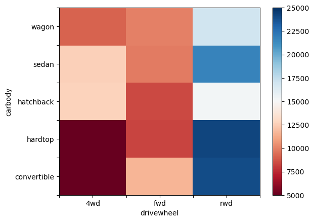

```
                       price                                        \
enginetype              dohc             l           ohc      ohcf
enginelocation
front           19138.269231  14627.583333  11574.048426   8541.25
rear                     NaN           NaN           NaN  34528.00


enginetype              ohcv    rotor
enginelocation
front           25098.384615  13020.0
rear                     NaN      NaN
```

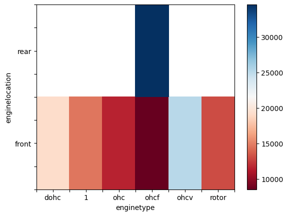

```python
# check price for fueltype vs aspiration
df_test_1 = df[["fueltype","aspiration","price"]]
df_grp_1 = df_test_1.groupby(["fueltype","aspiration"],as_index=False).mean()
df_pivot_1 = df_grp_1.pivot(index="fueltype",columns="aspiration")
print(df_pivot_1)
plt.pcolor(df_pivot_1,cmap='RdBu')
plt.xlabel('aspiration')
plt.ylabel('fuel type')
plt.xticks([0.0,0.25,0.50,0.75,1.00,1.25,1.5,1.75,2.0],["","","std","","","","turbo","",""])
plt.yticks([0.0,0.25,0.50,0.75,1.00,1.25,1.5,1.75,2.0],["","","diesel","","","","gas","",""])
plt.colorbar()
#plt.clim(df['price'].min(),df['price'].max())
plt.clim(5000,25000)
plt.show()

# check price for carbody vs drivewheel
df_test_2 = df[["carbody","drivewheel","price"]]
df_grp_2 = df_test_2.groupby(["carbody","drivewheel"],as_index=False).mean()
df_pivot_2 = df_grp_2.pivot(index="carbody",columns="drivewheel")
df_pivot_2.replace(np.nan,0,inplace=True)
print(df_pivot_2)
plt.pcolor(df_pivot_2,cmap='RdBu')
plt.xlabel('drivewheel')
plt.ylabel('carbody')
plt.xticks([0.0,0.50,1.00,1.5,2.0,2.5,3.0],["","4wd","","fwd","","rwd",""])
plt.yticks([0.0,0.50,1.00,1.5,2.0,2.5,3.0,3.5,4.0,4.5,5.0],["","convertible","","hardtop","","hatchback","","sedan","","wagon",""])
plt.colorbar()
plt.clim(5000,25000)
plt.show()

# check price for enginelocation vs enginetype
df_test_3 = df[["enginelocation","enginetype","price"]]
df_grp_3 = df_test_3.groupby(["enginelocation","enginetype"],as_index=False).mean()
df_pivot_3 = df_grp_3.pivot(index="enginelocation",columns="enginetype")
#df_pivot_3.replace(np.nan,0,inplace=True)
print(df_pivot_3)
plt.pcolor(df_pivot_3,cmap='RdBu')
plt.xlabel('enginetype')
plt.ylabel('enginelocation')
plt.xticks([0.0,0.50,1.00,1.5,2.0,2.5,3.0,3.5,4.0,4.5,5.0,5.5,6.0],["","dohc","","1","","ohc","","ohcf","","ohcv","","rotor",""])
plt.yticks([0.0,0.25,0.50,0.75,1.0,1.25,1.50,1.75,2.0],["","","front","","","","rear","",""])
plt.colorbar()
#plt.clim(5000,25000)
plt.show()
```

Now, we utilize box plots and anova tests in order to decide which categorical variables influence mostly the car's price and then apply to those an anova (analysis of variance). If the scores of the anova suggest that the categorical variable affects significantly the price then we will proceed with a one-hot encoding.

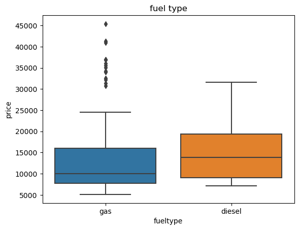

```
F-score= 2.2927407366575174 p-value= 0.13153563336537924
```

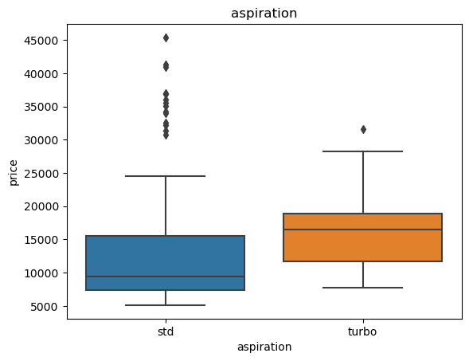

```
F-score= 6.636621968649918 p-value= 0.010700300833183433
            count
aspiration
std           168
turbo          37
```

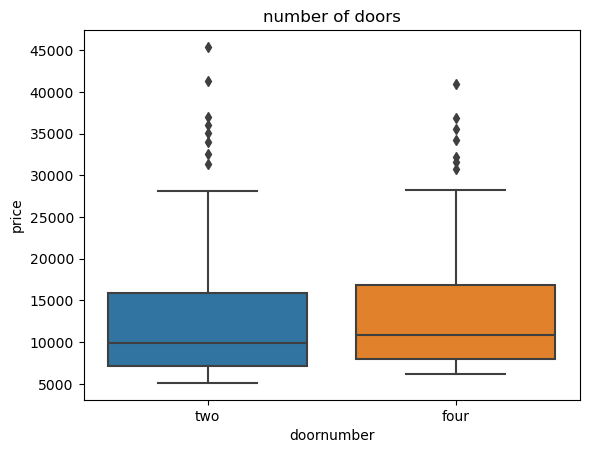

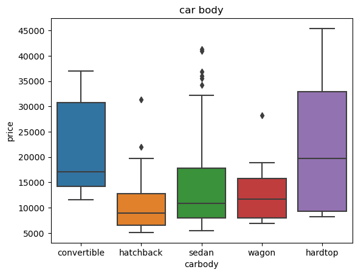

```
F-score= 4.321080183565251 p-value= 0.040202859433924154
             count
carbody
sedan           96
hatchback       70
wagon           25
hardtop          8
convertible      6
```

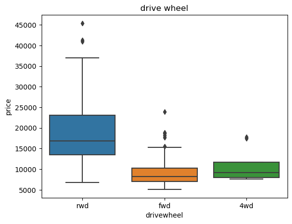

```
F-score= 2.2927407366575174 p-value= 0.13153563336537924
```

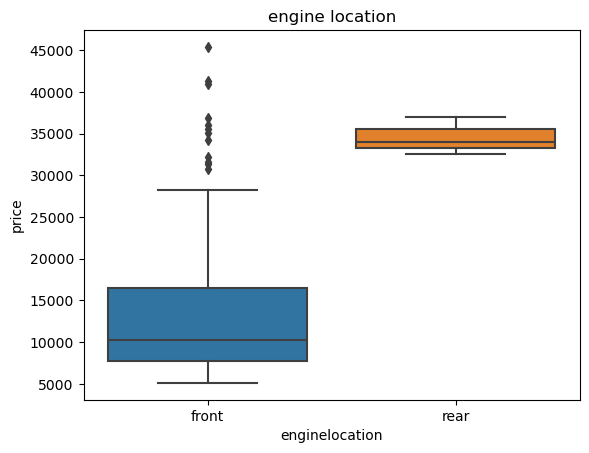

```
F-score= 23.9697400547047 p-value= 1.993019639057392e-06
                count
enginelocation
front             202
rear                3
```

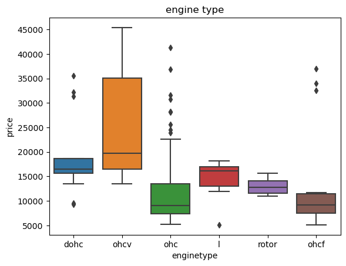

```
F-score= 45.68629797118885 p-value= 2.4933927905909703e-10
            count
enginetype
ohc           148
ohcf           15
dohc           13
ohcv           13
l              12
rotor           4
```

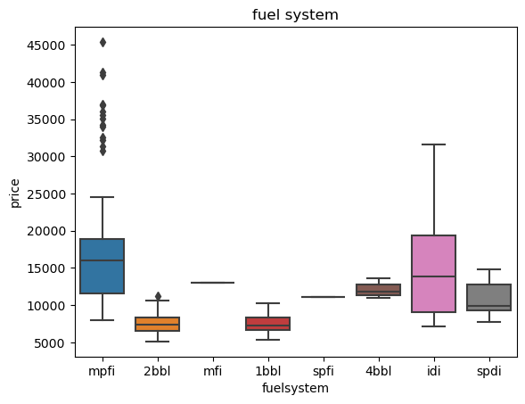

```
F-score= 71.01677520513671 p-value= 8.434440270694445e-13
            count
fuelsystem
mpfi           94
2bbl           66
idi            20
1bbl           11
spdi            9
4bbl            3
mfi             1
spfi            1
   car_ID  symboling              CarName fueltype aspiration doornumber  \
0       1        1.0   alfa-romero giulia      gas        std        two
1       2        1.0  alfa-romero stelvio      gas        std        two

       carbody drivewheel enginelocation  wheelbase  carlength  carwidth  \
0  convertible        rwd          front   0.058309   0.413433  0.316667
1  convertible        rwd          front   0.058309   0.413433  0.316667

   carheight  ...   peakrpm city-km/L  highway-km/L    price  \
0   0.083333  ...  0.346939  0.222222      0.289474  13495.0
1   0.083333  ...  0.346939  0.222222      0.289474  16500.0

          price_cat  1bbl  2bbl  4bbl  idi  mfi  mpfi  spdi  spfi
0  very low (5-15k)     0     0     0    0    0     1     0     0
1      low (15-25k)     0     0     0    0    0     1     0     0

[2 rows x 35 columns]
```

```python
# check fueltype ################################################
import seaborn as sns
sns.boxplot(x='fueltype',y='price',data=df)
plt.title('fuel type')
plt.show()
plt.close()

import scipy.stats as stats
df_fueltype = df[['fueltype','price']]
df_grp_fueltype = df_fueltype.groupby(['fueltype'])
anova_fueltype = stats.f_oneway(df_grp_fueltype.get_group('gas')['price'],df_grp_fueltype.get_group('diesel')['price'])
print('F-score=',anova_fueltype[0],'p-value=',anova_fueltype[1])
###################################################################

# check aspiration ################################################
sns.boxplot(x='aspiration',y='price',data=df)
plt.title('aspiration')
plt.show()
plt.close()

df_aspiration = df[['aspiration','price']]
df_grp_aspiration = df_aspiration.groupby(['aspiration'])
anova_aspiration = stats.f_oneway(df_grp_aspiration.get_group('std')['price'],df_grp_aspiration.get_group('turbo')['price'])
print('F-score=',anova_aspiration[0],'p-value=',anova_aspiration[1])

# we want to check if there are enough entries of std & turbo
df_aspiration_counts = df['aspiration'].value_counts().to_frame()
df_aspiration_counts.rename(columns={'aspiration':'counts'},inplace=True)
df_aspiration_counts.index.name='aspiration'
print(df_aspiration_counts)
#########################################################################


# check doornumber #################################################
sns.boxplot(x='doornumber',y='price',data=df)
plt.title('number of doors')
plt.show()
plt.close()
#####################################################################

# check carbody #####################################################
sns.boxplot(x='carbody',y='price',data=df)
plt.title('car body')
plt.show()
plt.close()

df_carbody = df[['carbody','price']]
df_grp_carbody = df_carbody.groupby(['carbody'])
anova_carbody = stats.f_oneway(df_grp_carbody.get_group('convertible')['price'],df_grp_carbody.get_group('sedan')['price'])
print('F-score=',anova_carbody[0],'p-value=',anova_carbody[1])

# we want to check if there are enough entries of convertibles & sedans
df_carbody_counts = df['carbody'].value_counts().to_frame()
df_carbody_counts.rename(columns={'carbody':'counts'},inplace=True)
df_carbody_counts.index.name='carbody'
print(df_carbody_counts)
######################################################################

# check drivewheel ###################################################
sns.boxplot(x='drivewheel',y='price',data=df)
plt.title('drive wheel')
plt.show()
plt.close()

df_drivewheel = df[['drivewheel','price']]
df_grp_drivewheel = df_drivewheel.groupby(['drivewheel'])
anova_drivewheel = stats.f_oneway(df_grp_drivewheel.get_group('rwd')['price'],df_grp_drivewheel.get_group('4wd')['price'])
print('F-score=',anova_fueltype[0],'p-value=',anova_fueltype[1])
#######################################################################

# check enginelocation ################################################
sns.boxplot(x='enginelocation',y='price',data=df)
plt.title('engine location')
plt.show()
plt.close()

df_enginelocation = df[['enginelocation','price']]
df_grp_enginelocation = df_enginelocation.groupby(['enginelocation'])
anova_enginelocation = stats.f_oneway(df_grp_enginelocation.get_group('front')['price'],df_grp_enginelocation.get_group('rear')['price'])
print('F-score=',anova_enginelocation[0],'p-value=',anova_enginelocation[1])

# we want to check if there are enough entries of front & rear
df_enginelocation_counts = df['enginelocation'].value_counts().to_frame()
df_enginelocation_counts.rename(columns={'enginelocation':'counts'},inplace=True)
df_enginelocation_counts.index.name='enginelocation'
print(df_enginelocation_counts)
#########################################################################

# check enginetype #####################################################
sns.boxplot(x='enginetype',y='price',data=df)
plt.title('engine type')
plt.show()
plt.close()

df_enginetype = df[['enginetype','price']]
df_grp_enginetype = df_enginetype.groupby(['enginetype'])
anova_enginetype = stats.f_oneway(df_grp_enginetype.get_group('ohcv')['price'],df_grp_enginetype.get_group('ohc')['price'])
print('F-score=',anova_enginetype[0],'p-value=',anova_enginetype[1])

# we want to check if there are enough entries of ohcv & ohc
df_enginetype_counts = df['enginetype'].value_counts().to_frame()
df_enginetype_counts.rename(columns={'enginetype':'counts'},inplace=True)
df_enginetype_counts.index.name='enginetype'
print(df_enginetype_counts)
#########################################################################

# check fuelsystem ######################################################
sns.boxplot(x='fuelsystem',y='price',data=df)
plt.title('fuel system')
plt.show()
plt.close()

df_fuelsystem = df[['fuelsystem','price']]
df_grp_fuelsystem = df_fuelsystem.groupby(['fuelsystem'])
anova_fuelsystem = stats.f_oneway(df_grp_fuelsystem.get_group('idi')['price'],df_grp_fuelsystem.get_group('2bbl')['price'])
print('F-score=',anova_fuelsystem[0],'p-value=',anova_fuelsystem[1])

# we want to check if there are enough entries of idi & 2bbl
df_fuelsystem_counts = df['fuelsystem'].value_counts().to_frame()
df_fuelsystem_counts.rename(columns={'fuelsystem':'counts'},inplace=True)
df_fuelsystem_counts.index.name='fuelsystem'
print(df_fuelsystem_counts)

# we proceed with the one-hot encoding
pinakas = pd.get_dummies(df['fuelsystem'],dtype=int)
df = pd.concat([df,pinakas],axis=1)
print(df.head(2))
#########################################################################
```

We continue with the numerical variables to examine which influence mostly the car's price. We will base our analysis on scatter plots to examine their relationship, and calculate the Pearson correlation coefficient if we detect any linear relationship between the price and the examined variable.

[figure not shown]

[figure not shown]

[figure not shown]

[figure not shown]

[figure not shown]

```
price               1.000000
symboling          -0.079978
wheelbase           0.577816
carlength           0.682920
carwidth            0.759325
carheight           0.119336
curbweight          0.835305
cylindernumber      0.718305
enginesize          0.874145
boreratio           0.553173
stroke              0.079443
compressionratio    0.067984
horsepower          0.808139
peakrpm            -0.085267
city-km/L          -0.685751
highway-km/L       -0.697599
Name: price, dtype: float64
```

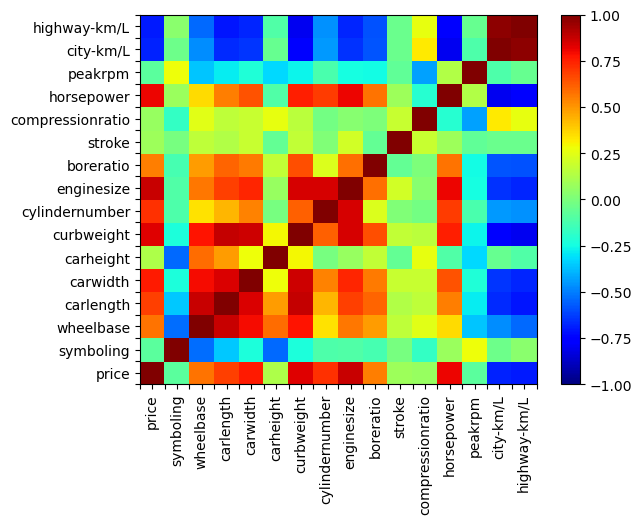

```python
######################### first 3 num. variables #########################################################
plt.figure(figsize=(14,4))

plt.subplot(1,3,1)
plt.scatter(df['symboling'],df['price'],s=5)
plt.xlabel('symboling'); plt.ylabel('price');plt.title('symboling')
plt.yticks([5000,10000,15000,20000,25000,30000,35000,40000,45000],["50k","100k","150k","200k","250k","300k","350k","400k","450k"])

plt.subplot(1,3,2)
plt.scatter(df['wheelbase'],df['price'],s=5)
plt.xlabel('wheelbase');plt.title('wheelbase')
plt.yticks([5000,10000,15000,20000,25000,30000,35000,40000,45000],["","","","","","","","",""])

plt.subplot(1,3,3)
plt.scatter(df['carlength'],df['price'],s=5)
plt.xlabel('carlength');plt.title('carlength')
plt.yticks([5000,10000,15000,20000,25000,30000,35000,40000,45000],["","","","","","","","",""])

plt.show()
plt.close()

###########################################################################################################

######################### next 3 num. variables ###########################################################
plt.figure(figsize=(14,4))

plt.subplot(1,3,1)
plt.scatter(df['carwidth'],df['price'],s=5)
plt.xlabel('carwidth'); plt.ylabel('price');plt.title('carwidth')
plt.yticks([5000,10000,15000,20000,25000,30000,35000,40000,45000],["50k","100k","150k","200k","250k","300k","350k","400k","450k"])

plt.subplot(1,3,2)
plt.scatter(df['carheight'],df['price'],s=5)
plt.xlabel('carheight');plt.title('carheight')
plt.yticks([5000,10000,15000,20000,25000,30000,35000,40000,45000],["","","","","","","","",""])

plt.subplot(1,3,3)
plt.scatter(df['curbweight'],df['price'],s=5)
plt.xlabel('curbweight');plt.title('curbweight')
plt.yticks([5000,10000,15000,20000,25000,30000,35000,40000,45000],["","","","","","","","",""])

plt.show()
plt.close()
###########################################################################################################

######################### next 3 num. variables ###########################################################
plt.figure(figsize=(14,4))

plt.subplot(1,3,1)
plt.scatter(df['cylindernumber'],df['price'],s=5)
plt.xlabel('cylindernumber'); plt.ylabel('price');plt.title('cylindernumber')
plt.yticks([5000,10000,15000,20000,25000,30000,35000,40000,45000],["50k","100k","150k","200k","250k","300k","350k","400k","450k"])

plt.subplot(1,3,2)
plt.scatter(df['enginesize'],df['price'],s=5)
plt.xlabel('enginesize');plt.title('enginesize')
plt.yticks([5000,10000,15000,20000,25000,30000,35000,40000,45000],["","","","","","","","",""])

plt.subplot(1,3,3)
plt.scatter(df['boreratio'],df['price'],s=5)
plt.xlabel('boreratio');plt.title('boreratio')
plt.yticks([5000,10000,15000,20000,25000,30000,35000,40000,45000],["","","","","","","","",""])

plt.show()
plt.close()
###########################################################################################################

######################### next 3 num. variables ###########################################################
plt.figure(figsize=(14,4))

plt.subplot(1,3,1)
plt.scatter(df['stroke'],df['price'],s=5)
plt.xlabel('stroke'); plt.ylabel('price');plt.title('stroke')
plt.yticks([5000,10000,15000,20000,25000,30000,35000,40000,45000],["50k","100k","150k","200k","250k","300k","350k","400k","450k"])

plt.subplot(1,3,2)
plt.scatter(df['compressionratio'],df['price'],s=5)
plt.xlabel('compressionratio');plt.title('compressionratio')
plt.yticks([5000,10000,15000,20000,25000,30000,35000,40000,45000],["","","","","","","","",""])

plt.subplot(1,3,3)
plt.scatter(df['horsepower'],df['price'],s=5)
plt.xlabel('horsepower');plt.title('horsepower')
plt.yticks([5000,10000,15000,20000,25000,30000,35000,40000,45000],["","","","","","","","",""])

plt.show()
plt.close()
###########################################################################################################

######################### next 3 num. variables ###########################################################
plt.figure(figsize=(14,4))

plt.subplot(1,3,1)
plt.scatter(df['peakrpm'],df['price'],s=5)
plt.xlabel('peakrpm'); plt.ylabel('price');plt.title('peakrpm')
plt.yticks([5000,10000,15000,20000,25000,30000,35000,40000,45000],["50k","100k","150k","200k","250k","300k","350k","400k","450k"])

plt.subplot(1,3,2)
plt.scatter(df['city-km/L'],df['price'],s=5)
plt.xlabel('city-km/L');plt.title('city-km/L')
plt.yticks([5000,10000,15000,20000,25000,30000,35000,40000,45000],["","","","","","","","",""])

plt.subplot(1,3,3)
plt.scatter(df['highway-km/L'],df['price'],s=5)
plt.xlabel('highway-km/L');plt.title('highway-km/L')
plt.yticks([5000,10000,15000,20000,25000,30000,35000,40000,45000],["","","","","","","","",""])

plt.show()
plt.close()
#######################################################################################################

df_correlation = df[['price','symboling','wheelbase','carlength','carwidth','carheight','curbweight','cylindernumber','enginesize','boreratio','stroke','compressionratio','horsepower','peakrpm','city-km/L','highway-km/L']]
A = df_correlation.corr(method='pearson')
print(A['price'])
plt.pcolor(A,cmap='jet')
a_1=[0,0.5,1.0,1.5,2.0,2.5,3.0,3.5,4.0,4.5,5.0,5.5,6.0,6.5,7.0,7.5,8.0,8.5,9.0,9.5,10.0,10.5,11.0,11.5,12.0,12.5,13.0,13.5,14.0,14.5,15.0,15.5,16.0]
a_2=["","price","","symboling","","wheelbase","","carlength","","carwidth","","carheight","","curbweight","","cylindernumber","","enginesize","","boreratio","","stroke","","compressionratio","","horsepower","","peakrpm","","city-km/L","","highway-km/L",""]
plt.xticks(a_1,a_2,rotation=90)
plt.yticks(a_1,a_2)
plt.colorbar()
plt.clim(-1,1)
plt.show()
```

Before we proceed with the car's price analysis it is intersting to see that: engine size, horsepower, curbweight are positive correlated with each other but negatively correlated with highway and city km/L. As it was expected cars with big engine size will have a lot of curbweight and result in high horsepower. But, these cars will not cover many km per fuel liter as they are not designed to be fuel-efficient.

Back to our analysis, we infer from the figures that there is not clear relationship between "symboling","carheight","stroke","compressionratio","peakrpm" and price. There are no clear regression lines (which represents a function between our numeric var and price) that we can draw on these scatter plots. Thus, we exclude these variables from our model.

On the other hand, "wheelbase", "carlength", "carwidth", "curbweight", "cylindernumber", "enginesize", "horsepower", "city-km/L", and "highway-km/L" are variables that can be linearly correlated with price and we can assume a linear function that relates these variables with price. We notice that the relationship of these variables with price is more evident at low values rather than at high values where the points are more scattered. This is opposite for the case of the variables city and highway km/L where the relationship is vague at low values. Also, a quadratic function could better fit the carlength-price scatter plot.

Nevertheless, this is a good starting point and we calculate the pearson correlation coefficient assuming that a linear relationship with price is a good approximation of the truth. We will accept numeric variables that deduce correlation coefficients for price which are over ~0.7. Thus, we will consider:

1. enginesize (corr coef = + 0.87)
2. curbweight (corr coef = + 0.83)
3. horsepower (corr coef = + 0.80)
4. carwidth (corr coef = + 0.75)
5. cylinder number (corr coef = + 0.71)
6. carlength (corr coef = + 0.68)
7. highway-km/L (corr coef = -0.69)
8. city-km/L (corr coef = -0.68)
1. The first model we are going to build is a Single Linear Regression (SLR), with which we will try to predict car's price using as predictor the enginesize.
2. The second model will be a Multi Linear Regression (MLR), which will predict price based on enginesize, curbweight, and horsepower.
3. The third model will be a MLR, which will predict price based on enginesize, curbweight, horsepower, and cylindernumber.
4. The fourth model will be a MLR, which will predict the price based on carwidth, and carlength.
5. The fifth model will be a MLR, which will predict the price based on enginesize, curbweight, horsepower, cylindernumber, carwidth, carlength.
6. The sixth model will be a SLR, which will predict the price based on highway-km/L.
7. The seventh model will be a MLR, which will predict the price based on highway-km/L, and city-km/L.
8. The eight model will be a MLR, which will use all the aforementioned numerical variables.
9. The ninth model will be a one dimensional Polynomial second order, which will use as a predictor the carlength.
10. The tenth model will be a two dimensional Polynomial second order, which will be based on carlength, and enginesize.

Lets start with the 1st model - SLR:enginesize

```
MSE in-sample= 15241919.529579677
R^2 in-sample= 0.7557897278380871
MSE out-of-sample= 14541824.671847729
R^2 out-of-sample= 0.6584173707010581
```

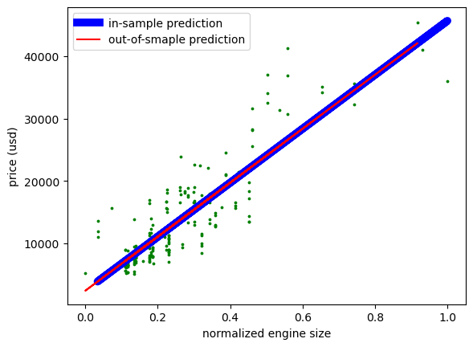

```python
# we define predictor (X) and response variable (Y)
X_data_1 = df[['enginesize']]; Y_data_1 = df['price']

# we split the data into a training set (X_train, Y_train) and a test set (X_test, Y_test)
from sklearn.model_selection import train_test_split
X_train_1,X_test_1,Y_train_1,Y_test_1 = train_test_split(X_data_1,Y_data_1,test_size=0.3,random_state=0)

# we fit the SLM to the train set
from sklearn.linear_model import LinearRegression
SLR_1 = LinearRegression()
SLR_1.fit(X_train_1,Y_train_1)

# we make our prediction using the train and test set
Y_hat_in_1 = SLR_1.predict(X_train_1)
Y_hat_out_1 = SLR_1.predict(X_test_1)

# we conduct the in-sample evaluation by calculating the MSE and R_squared
from sklearn.metrics import mean_squared_error
MSE_in_1 = mean_squared_error(Y_train_1,Y_hat_in_1)
print("MSE in-sample=",MSE_in_1)
R_in_1 = SLR_1.score(X_train_1,Y_train_1)
print("R^2 in-sample=",R_in_1)

# we conduct the out-of-smaple evaluation by calculating the mean R_squared from cross-validation with 3 partitions of our data
MSE_out_1 = mean_squared_error(Y_test_1,Y_hat_out_1)
print("MSE out-of-sample=",MSE_out_1)
from sklearn.model_selection import cross_val_score
scores = cross_val_score(SLR_1,X_data_1,Y_data_1,cv=3)
R_out_1 = np.mean(scores)
print("R^2 out-of-sample=",R_out_1)

plt.scatter(X_data_1,Y_data_1,c='green',s=3)
plt.plot(X_train_1,Y_hat_in_1,c='blue',label="in-sample prediction",linewidth=7.0)
plt.plot(X_test_1,Y_hat_out_1,label="out-of-smaple prediction",c='red')
plt.legend()
plt.xlabel('normalized engine size')
plt.ylabel('price (usd)')
plt.show()
```

2nd model - MLR:enginesize-curbweight-horsepower

```python
# we define predictor (X) and response variable (Y)
X_data_2 = df[['enginesize','curbweight','horsepower']]; Y_data_2 = df['price']

# we split the data into a training set (X_train, Y_train) and a test set (X_test, Y_test)
X_train_2,X_test_2,Y_train_2,Y_test_2 = train_test_split(X_data_2,Y_data_2,test_size=0.3,random_state=0)

# we fit the SLM to the train set
MLR_2 = LinearRegression()
MLR_2.fit(X_train_2,Y_train_2)

# we make our prediction using the train and test set
Y_hat_in_2 = MLR_2.predict(X_train_2)
Y_hat_out_2 = MLR_2.predict(X_test_2)

# we conduct the in-sample evaluation by calculating the MSE and R_squared
MSE_in_2 = mean_squared_error(Y_train_2,Y_hat_in_2)
print("MSE in-sample=",MSE_in_2)
R_in_2 = MLR_2.score(X_train_2,Y_train_2)
print("R^2 in-sample=",R_in_2)

# we conduct the out-of-smaple evaluation by calculating the mean R_squared from cross-validation with 3 partitions of our data
MSE_out_2 = mean_squared_error(Y_test_2,Y_hat_out_2)
print("MSE out-of-sample=",MSE_out_2)
scores = cross_val_score(MLR_2,X_data_2,Y_data_2,cv=3)
R_out_2 = np.mean(scores)
print("R^2 out-of-sample=",R_out_2)
```

```
MSE in-sample= 11764579.21749095
R^2 in-sample= 0.8115046410658304
MSE out-of-sample= 12421257.151345119
R^2 out-of-sample= 0.7117021497639664
```

3rd model - MLR:enginesize-curbweight-horsepower-cylindernumber

```python
# we define predictor (X) and response variable (Y)
X_data_3 = df[['enginesize','curbweight','horsepower','cylindernumber']]; Y_data_3 = df['price']

# we split the data into a training set (X_train, Y_train) and a test set (X_test, Y_test)
X_train_3,X_test_3,Y_train_3,Y_test_3 = train_test_split(X_data_3,Y_data_3,test_size=0.3,random_state=0)

# we fit the SLM to the train set
MLR_3 = LinearRegression()
MLR_3.fit(X_train_3,Y_train_3)

# we make our prediction using the train and test set
Y_hat_in_3 = MLR_3.predict(X_train_3)
Y_hat_out_3 = MLR_3.predict(X_test_3)

# we conduct the in-sample evaluation by calculating the MSE and R_squared
MSE_in_3 = mean_squared_error(Y_train_3,Y_hat_in_3)
print("MSE in-sample=",MSE_in_3)
R_in_3 = MLR_3.score(X_train_3,Y_train_3)
print("R^2 in-sample=",R_in_3)

# we conduct the out-of-smaple evaluation by calculating the mean R_squared from cross-validation with 3 partitions of our data
MSE_out_3 = mean_squared_error(Y_test_3,Y_hat_out_3)
print("MSE out-of-sample=",MSE_out_3)
scores = cross_val_score(MLR_3,X_data_3,Y_data_3,cv=3)
R_out_3 = np.mean(scores)
print("R^2 out-of-sample=",R_out_3)
```

```
MSE in-sample= 11761176.864470743
R^2 in-sample= 0.8115591545118201
MSE out-of-sample= 12405238.296321696
R^2 out-of-sample= 0.7000976007597268
```

4th model - MLR:carwidth-carlength

```python
# we define predictor (X) and response variable (Y)
X_data_4 = df[['carwidth','carlength']]; Y_data_4 = df['price']

# we split the data into a training set (X_train, Y_train) and a test set (X_test, Y_test)
X_train_4,X_test_4,Y_train_4,Y_test_4 = train_test_split(X_data_4,Y_data_4,test_size=0.3,random_state=0)

# we fit the SLM to the train set
MLR_4 = LinearRegression()
MLR_4.fit(X_train_4,Y_train_4)

# we make our prediction using the train and test set
Y_hat_in_4 = MLR_4.predict(X_train_4)
Y_hat_out_4 = MLR_4.predict(X_test_4)

# we conduct the in-sample evaluation by calculating the MSE and R_squared
MSE_in_4 = mean_squared_error(Y_train_4,Y_hat_in_4)
print("MSE in-sample=",MSE_in_4)
R_in_4 = MLR_4.score(X_train_4,Y_train_4)
print("R^2 in-sample=",R_in_4)

# we conduct the out-of-smaple evaluation by calculating the mean R_squared from cross-validation with 3 partitions of our data
MSE_out_4 = mean_squared_error(Y_test_4,Y_hat_out_4)
print("MSE out-of-sample=",MSE_out_4)
scores = cross_val_score(MLR_4,X_data_4,Y_data_4,cv=3)
R_out_4 = np.mean(scores)
print("R^2 out-of-sample=",R_out_4)
```

```
MSE in-sample= 28369070.096592322
R^2 in-sample= 0.5454628719286875
MSE out-of-sample= 22093267.407264527
R^2 out-of-sample= 0.44567153018172534
```

From the MSE and R squared comparsion (in & out-of sample) of the 2nd & 3rd models we infer that cylindernumber does not result in much better price prediction. Thus, we decide to exclude it from now on and the 5th & 8th models will not consider it.

5th model - MLR:enginesize-curbweight-horsepower-carwidth-carlength

```python
# we define predictor (X) and response variable (Y)
X_data_5 = df[['enginesize','curbweight','horsepower','carwidth','carlength']]; Y_data_5 = df['price']

# we split the data into a training set (X_train, Y_train) and a test set (X_test, Y_test)
X_train_5,X_test_5,Y_train_5,Y_test_5 = train_test_split(X_data_5,Y_data_5,test_size=0.3,random_state=0)

# we fit the SLM to the train set
MLR_5 = LinearRegression()
MLR_5.fit(X_train_5,Y_train_5)

# we make our prediction using the train and test set
Y_hat_in_5 = MLR_5.predict(X_train_5)
Y_hat_out_5 = MLR_5.predict(X_test_5)

# we conduct the in-sample evaluation by calculating the MSE and R_squared
MSE_in_5 = mean_squared_error(Y_train_5,Y_hat_in_5)
print("MSE in-sample=",MSE_in_5)
R_in_5 = MLR_5.score(X_train_5,Y_train_5)
print("R^2 in-sample=",R_in_5)

# we conduct the out-of-smaple evaluation by calculating the mean R_squared from cross-validation with 3 partitions of our data
MSE_out_5 = mean_squared_error(Y_test_5,Y_hat_out_5)
print("MSE out-of-sample=",MSE_out_5)
scores = cross_val_score(MLR_5,X_data_5,Y_data_5,cv=3)
R_out_5 = np.mean(scores)
print("R^2 out-of-sample=",R_out_5)
```

```
MSE in-sample= 11247478.67092003
R^2 in-sample= 0.8197897697839087
MSE out-of-sample= 12555233.421857364
R^2 out-of-sample= 0.7151797927693693
```

6th model -SLR:highway-km/L

```
MSE in-sample= 30582447.86947894
R^2 in-sample= 0.5099995179026559
MSE out-of-sample= 38403565.468197644
R^2 out-of-sample= 0.30186636109622517
```

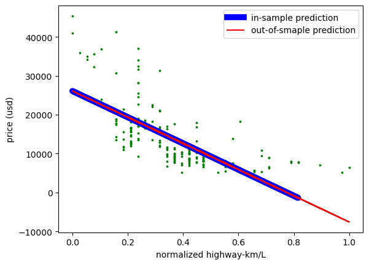

```python
# we define predictor (X) and response variable (Y)
X_data_6 = df[['highway-km/L']]; Y_data_6 = df['price']

# we split the data into a training set (X_train, Y_train) and a test set (X_test, Y_test)
X_train_6,X_test_6,Y_train_6,Y_test_6 = train_test_split(X_data_6,Y_data_6,test_size=0.3,random_state=0)

# we fit the SLM to the train set
SLR_6 = LinearRegression()
SLR_6.fit(X_train_6,Y_train_6)

# we make our prediction using the train and test set
Y_hat_in_6 = SLR_6.predict(X_train_6)
Y_hat_out_6 = SLR_6.predict(X_test_6)

# we conduct the in-sample evaluation by calculating the MSE and R_squared
MSE_in_6 = mean_squared_error(Y_train_6,Y_hat_in_6)
print("MSE in-sample=",MSE_in_6)
R_in_6 = SLR_6.score(X_train_6,Y_train_6)
print("R^2 in-sample=",R_in_6)

# we conduct the out-of-smaple evaluation by calculating the mean R_squared from cross-validation with 3 partitions of our data
MSE_out_6 = mean_squared_error(Y_test_6,Y_hat_out_6)
print("MSE out-of-sample=",MSE_out_6)
scores = cross_val_score(SLR_6,X_data_6,Y_data_6,cv=3)
R_out_6 = np.mean(scores)
print("R^2 out-of-sample=",R_out_6)

plt.scatter(X_data_6,Y_data_6,c='green',s=3)
plt.plot(X_train_6,Y_hat_in_6,c='blue',label="in-sample prediction",linewidth=7.0)
plt.plot(X_test_6,Y_hat_out_6,label="out-of-smaple prediction",c='red')
plt.legend()
plt.xlabel('normalized highway-km/L')
plt.ylabel('price (usd)')
plt.show()
```

The above model is an example of an example that fitting a straight line in the data does not always work. The prediction does not even make sence for higher km/L values since the price becomes negative. Only a small portion of the dataset of highway-km/L can be predicted fairly by this regression line(~0.2 to ~0.6). A Reciprocal function F(x)=1/x should be a better fit for these data points.

7th model - MLR:highway-km/L - city-km/L

```python
# we define predictor (X) and response variable (Y)
X_data_7 = df[['highway-km/L','city-km/L']]; Y_data_7 = df['price']

# we split the data into a training set (X_train, Y_train) and a test set (X_test, Y_test)
X_train_7,X_test_7,Y_train_7,Y_test_7 = train_test_split(X_data_7,Y_data_7,test_size=0.3,random_state=0)

# we fit the SLM to the train set
MLR_7 = LinearRegression()
MLR_7.fit(X_train_7,Y_train_7)

# we make our prediction using the train and test set
Y_hat_in_7 = MLR_7.predict(X_train_7)
Y_hat_out_7 = MLR_7.predict(X_test_7)

# we conduct the in-sample evaluation by calculating the MSE and R_squared
MSE_in_7 = mean_squared_error(Y_train_7,Y_hat_in_7)
print("MSE in-sample=",MSE_in_7)
R_in_7 = MLR_7.score(X_train_7,Y_train_7)
print("R^2 in-sample=",R_in_7)

# we conduct the out-of-smaple evaluation by calculating the mean R_squared from cross-validation with 3 partitions of our data
MSE_out_7 = mean_squared_error(Y_test_7,Y_hat_out_7)
print("MSE out-of-sample=",MSE_out_7)
scores = cross_val_score(MLR_7,X_data_7,Y_data_7,cv=3)
R_out_7 = np.mean(scores)
print("R^2 out-of-sample=",R_out_7)
```

```
MSE in-sample= 30454843.041895527
R^2 in-sample= 0.5120440379260587
MSE out-of-sample= 38527108.59528684
R^2 out-of-sample= 0.2572655226659298
```

The addition of an city-km/L that has almost the same relationship with price as the highway-km/L did not make the model any better. Therefore, we continue our search.

8th model - MLR:all numeric variables (except for cylinder number and one-hot encoded fuelsystem)

```python
# we define predictor (X) and response variable (Y)
X_data_8 = df[['enginesize','curbweight','horsepower','carwidth','carlength','highway-km/L','city-km/L']]; Y_data_8 = df['price']

# we split the data into a training set (X_train, Y_train) and a test set (X_test, Y_test)
X_train_8,X_test_8,Y_train_8,Y_test_8 = train_test_split(X_data_8,Y_data_8,test_size=0.3,random_state=0)

# we fit the SLM to the train set
MLR_8 = LinearRegression()
MLR_8.fit(X_train_8,Y_train_8)

# we make our prediction using the train and test set
Y_hat_in_8 = MLR_8.predict(X_train_8)
Y_hat_out_8 = MLR_8.predict(X_test_8)

# we conduct the in-sample evaluation by calculating the MSE and R_squared
MSE_in_8 = mean_squared_error(Y_train_8,Y_hat_in_8)
print("MSE in-sample=",MSE_in_8)
R_in_8 = MLR_8.score(X_train_8,Y_train_8)
print("R^2 in-sample=",R_in_8)

# we conduct the out-of-smaple evaluation by calculating the mean R_squared from cross-validation with 3 partitions of our data
MSE_out_8 = mean_squared_error(Y_test_8,Y_hat_out_8)
print("MSE out-of-sample=",MSE_out_8)
scores = cross_val_score(MLR_8,X_data_8,Y_data_8,cv=3)
R_out_8 = np.mean(scores)
print("R^2 out-of-sample=",R_out_8)
```

```
MSE in-sample= 11149033.583345316
R^2 in-sample= 0.8213670843460915
MSE out-of-sample= 12981892.87810874
R^2 out-of-sample= 0.707609736984241
```

Let's add to the above model the one-hot encoded fuelsystem columns. This model will be named "8plus".

```python
# we define predictor (X) and response variable (Y)
X_data_8plus = df[['enginesize','curbweight','horsepower','carwidth','carlength','highway-km/L','city-km/L','1bbl','2bbl','4bbl','idi','mfi','mpfi','spdi','spfi']]; Y_data_8plus = df['price']

# we split the data into a training set (X_train, Y_train) and a test set (X_test, Y_test)
X_train_8plus,X_test_8plus,Y_train_8plus,Y_test_8plus = train_test_split(X_data_8plus,Y_data_8plus,test_size=0.3,random_state=0)

# we fit the SLM to the train set
MLR_8plus = LinearRegression()
MLR_8plus.fit(X_train_8plus,Y_train_8plus)

# we make our prediction using the train and test set
Y_hat_in_8plus = MLR_8plus.predict(X_train_8plus)
Y_hat_out_8plus = MLR_8plus.predict(X_test_8plus)

# we conduct the in-sample evaluation by calculating the MSE and R_squared
MSE_in_8plus = mean_squared_error(Y_train_8plus,Y_hat_in_8plus)
print("MSE in-sample=",MSE_in_8plus)
R_in_8plus = MLR_8plus.score(X_train_8plus,Y_train_8plus)
print("R^2 in-sample=",R_in_8plus)

# we conduct the out-of-smaple evaluation by calculating the mean R_squared from cross-validation with 3 partitions of our data
MSE_out_8plus = mean_squared_error(Y_test_8plus,Y_hat_out_8plus)
print("MSE out-of-sample=",MSE_out_8plus)
scores = cross_val_score(MLR_8plus,X_data_8plus,Y_data_8plus,cv=3)
R_out_8plus = np.mean(scores)
print("R^2 out-of-sample=",R_out_8plus)
```

```
MSE in-sample= 9439215.102207195
R^2 in-sample= 0.848762271403461
MSE out-of-sample= 13206179.953126812
R^2 out-of-sample= 0.630246296070539
```

9th model - 1D Polynomial 2nd order:carlength

```
MSE in-sample= 32374912.11600549
R^2 in-sample= 0.4812801574155966
MSE out-of-sample= 28144508.129248112
R^2 out-of-sample= 0.30101092937056695
```

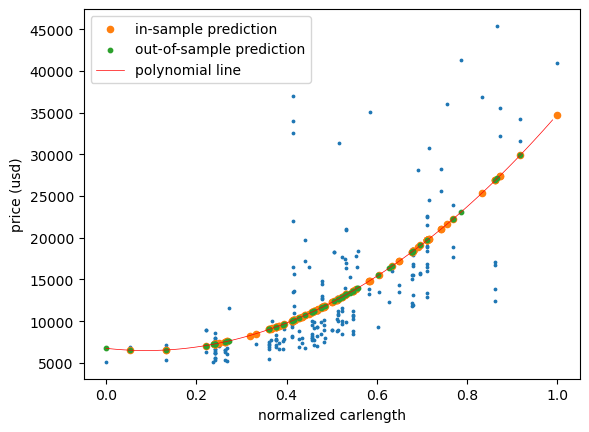

```python
# we define predictor (X) and response variable (Y)
X_data_9 = df[['carlength']]; Y_data_9 = df['price']

# we split the data into a training set (X_train, Y_train) and a test set (X_test, Y_test)
X_train_9,X_test_9,Y_train_9,Y_test_9 = train_test_split(X_data_9,Y_data_9,test_size=0.3,random_state=0)

# we fit the Polynomial model to the train set
from sklearn.preprocessing import PolynomialFeatures
pr_9 = PolynomialFeatures(degree=2)
X_train_pr_9 = pr_9.fit_transform(X_train_9)
X_test_pr_9 = pr_9.fit_transform(X_test_9)
lr_9 = LinearRegression()
lr_9.fit(X_train_pr_9,Y_train_9)

# we make the predictions for in & out-of the sample
Y_hat_in_9 = lr_9.predict(X_train_pr_9)
Y_hat_out_9 = lr_9.predict(X_test_pr_9)
X_plotting = pd.DataFrame({'1':np.arange(0,1,0.01)})
X_plotting_pr = pr_9.fit_transform(X_plotting)
Y_plotting = lr_9.predict(X_plotting_pr)

# we calculate the R squared and MSE for in & out-of the sample
R_in_9 = lr_9.score(X_train_pr_9,Y_train_9)
MSE_in_9 = mean_squared_error(Y_train_9,Y_hat_in_9)
print("MSE in-sample=",MSE_in_9)
print("R^2 in-sample=",R_in_9)

MSE_out_9 = mean_squared_error(Y_test_9,Y_hat_out_9)
print("MSE out-of-sample=",MSE_out_9)
scores = cross_val_score(lr_9,X_data_9,Y_data_9,cv=3)
R_out_9 = np.mean(scores)
print("R^2 out-of-sample=",R_out_9)


plt.scatter(X_data_9,Y_data_9,s=3)
plt.scatter(X_train_9,Y_hat_in_9,s=20,label='in-sample prediction')
plt.scatter(X_test_9,Y_hat_out_9,s=10,label='out-of-sample prediction')
plt.plot(X_plotting,Y_plotting,c='red',linewidth=0.5,label='polynomial line')
plt.legend()
plt.xlabel('normalized carlength')
plt.ylabel('price (usd)')
plt.show()
```

10th model - 2D Polynomial 2nd order:carlength-enginesize

```python
# we define predictor (X) and response variable (Y)
X_data_10 = df[['carlength','enginesize']]; Y_data_10 = df['price']

# we split the data into a training set (X_train, Y_train) and a test set (X_test, Y_test)
X_train_10,X_test_10,Y_train_10,Y_test_10 = train_test_split(X_data_10,Y_data_10,test_size=0.3,random_state=0)

# we fit the Polynomial model to the train set
pr_10 = PolynomialFeatures(degree=2)
X_train_pr_10 = pr_10.fit_transform(X_train_10)
X_test_pr_10 = pr_10.fit_transform(X_test_10)
lr_10 = LinearRegression()
lr_10.fit(X_train_pr_10,Y_train_10)

# we make the predictions for in & out-of the sample
Y_hat_in_10 = lr_10.predict(X_train_pr_10)
Y_hat_out_10 = lr_10.predict(X_test_pr_10)

# we calculate the R squared and MSE for in & out-of the sample
R_in_10 = lr_10.score(X_train_pr_10,Y_train_10)
MSE_in_10 = mean_squared_error(Y_train_10,Y_hat_in_10)
print("MSE in-sample=",MSE_in_10)
print("R^2 in-sample=",R_in_10)

MSE_out_10 = mean_squared_error(Y_test_10,Y_hat_out_10)
print("MSE out-of-sample=",MSE_out_10)
scores = cross_val_score(lr_10,X_data_10,Y_data_10,cv=3)
R_out_10 = np.mean(scores)
print("R^2 out-of-sample=",R_out_10)
```

```
MSE in-sample= 13828004.10786389
R^2 in-sample= 0.7784438738123547
MSE out-of-sample= 12095499.679575091
R^2 out-of-sample= 0.6589222405435143
```

Now, we gather all the MSE and R squared values in order to decide which model performs better

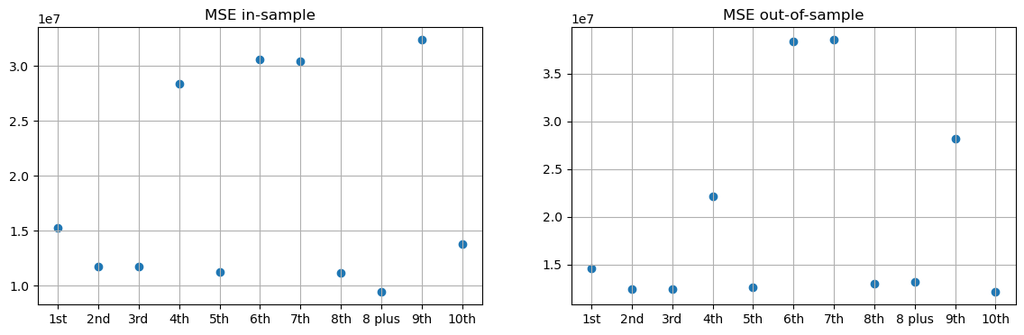

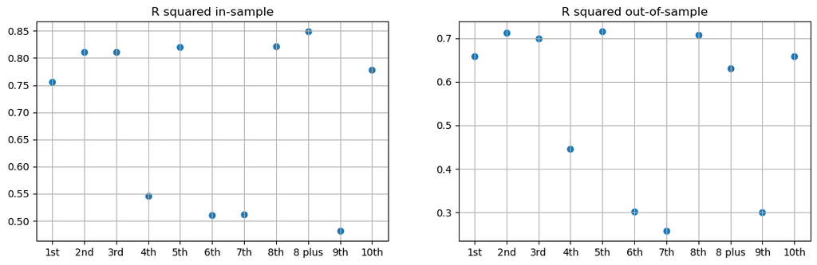

```python
MSE_IN_SAMPLE=[MSE_in_1,MSE_in_2,MSE_in_3,MSE_in_4,MSE_in_5,MSE_in_6,MSE_in_7,MSE_in_8,MSE_in_8plus,MSE_in_9,MSE_in_10]
MSE_OUT_SAMPLE=[MSE_out_1,MSE_out_2,MSE_out_3,MSE_out_4,MSE_out_5,MSE_out_6,MSE_out_7,MSE_out_8,MSE_out_8plus,MSE_out_9,MSE_out_10]

R_IN_SAMPLE=[R_in_1,R_in_2,R_in_3,R_in_4,R_in_5,R_in_6,R_in_7,R_in_8,R_in_8plus,R_in_9,R_in_10]
R_OUT_SAMPLE=[R_out_1,R_out_2,R_out_3,R_out_4,R_out_5,R_out_6,R_out_7,R_out_8,R_out_8plus,R_out_9,R_out_10]

models=[1,2,3,4,5,6,7,8,9,10,11]
names=['1st','2nd','3rd','4th','5th','6th','7th','8th','8 plus','9th','10th']

plt.figure(figsize=(14,4))
plt.subplot(1,2,1)
plt.scatter(models,MSE_IN_SAMPLE)
plt.title('MSE in-sample')
plt.xticks(models,names)
plt.grid(axis='both')

plt.subplot(1,2,2)
plt.scatter(models,MSE_OUT_SAMPLE)
plt.title('MSE out-of-sample')
plt.xticks(models,names)
plt.grid(axis='both')
plt.show()
plt.close()

plt.figure(figsize=(14,4))
plt.subplot(1,2,1)
plt.scatter(models,R_IN_SAMPLE)
plt.title('R squared in-sample')
plt.xticks(models,names)
plt.grid(axis='both')

plt.subplot(1,2,2)
plt.scatter(models,R_OUT_SAMPLE)
plt.title('R squared out-of-sample')
plt.xticks(models,names)
plt.grid(axis='both')
plt.show()
plt.close()
```

```
62
```

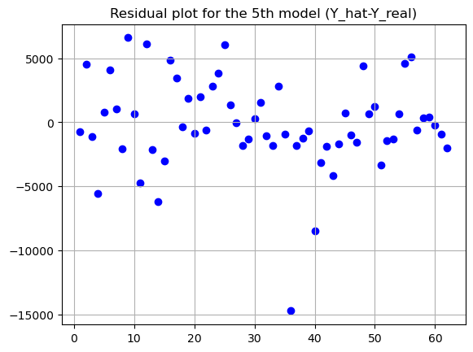

```
62
```

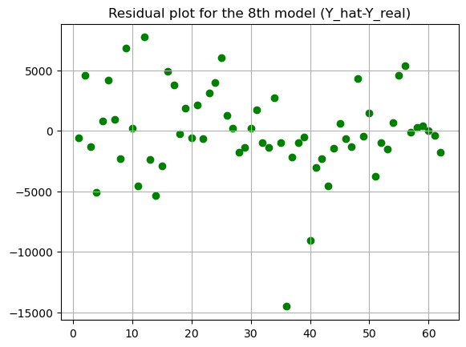

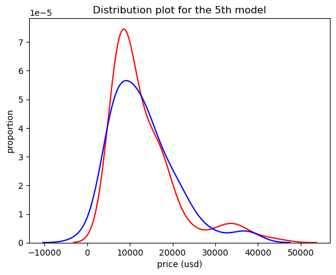

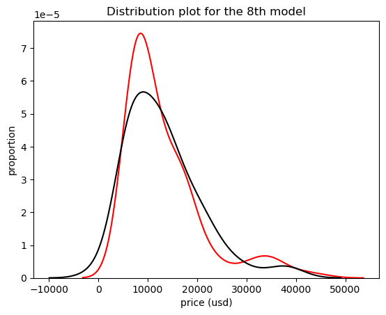

```python
error_5=[]
k=0
for i in Y_hat_out_5:
    error=i - Y_test_5.iloc[k]
    k=k+1
    error_5.append(error)
#print(error_5)
print(k);
xx = np.arange(1,k+1,1);
plt.scatter(xx,error_5,c='blue')
plt.title('Residual plot for the 5th model (Y_hat-Y_real)')
plt.grid(axis='both')
plt.show()

error_8=[]
k=0
for i in Y_hat_out_8:
    error=i - Y_test_8.iloc[k]
    k=k+1
    error_8.append(error)
#print(error_8)
print(k);
xx = np.arange(1,k+1,1);
plt.scatter(xx,error_8,c='green')
plt.title('Residual plot for the 8th model (Y_hat-Y_real)')
plt.grid(axis='both')
plt.show()


import seaborn as sns
ax1 = sns.distplot(df['price'],hist=False,color='red',label='Actual value')
sns.distplot(Y_hat_out_5,hist=False,color='blue',label='Fitted value',ax=ax1)
plt.title('Distribution plot for the 5th model')
plt.xlabel('price (usd)')
plt.ylabel('proportion')
plt.show()
plt.close()

ax2 = sns.distplot(df['price'],hist=False,color='red',label='Actual value')
sns.distplot(Y_hat_out_8,hist=False,color='black',label='Fitted value',ax=ax2)
plt.title('Distribution plot for the 8th model')
plt.xlabel('price (usd)')
plt.ylabel('proportion')
plt.show()
plt.close()
```

From the Residual and Distribution plots for the 5th and 8th models we cannot see a clear difference between them. The errors are close to zero and mostly confined between +/- 5k usd, and the distribution plots show almost the same overlapping with the real price area. Thus, which ever you choose you may have a good approximation of the car price. But beware that 10k and 30-40k you may have large deviations from the reality.